# Visualization III

MPA 634: Data Science for Managers

21 Jan 2021

# The R and RStudio Environments

Your workspace include the objects that you create during an R session. Don’t save your workspace when you close R. R is really good at accumulating objects and can greatly complicate finding errors.

## Assignment operator

In R, the “<-” is the assignment operator. We write object_name <- value and should be read object name gets value. The keyboard shortcut for “<-” is alt hyphen.

```r
(x <- seq(1, 100, 10))
```

```
##  [1]  1 11 21 31 41 51 61 71 81 91
```

## Piping symbol

A recent addition to R is the piping symbol "%>% which passes objects into function calls. It is currently part of tidyverse. Piping will become part of core R when 4.1 is released. Piping greatly simplifies coding with a sequence of calculations. The keyboard shortcut for piping %>% is ctrl shift m.

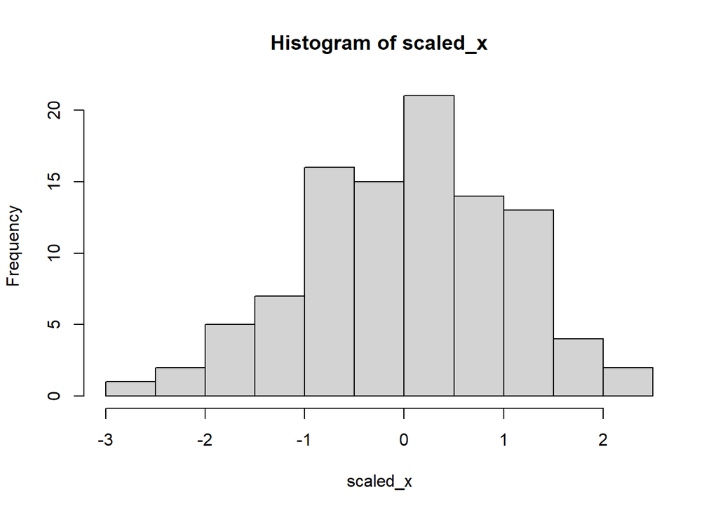

```r
# Chain of calculations using assignment operators
x <- rnorm(100, 10, 4)
scaled_x <- scale(x)
hist(scaled_x)
```

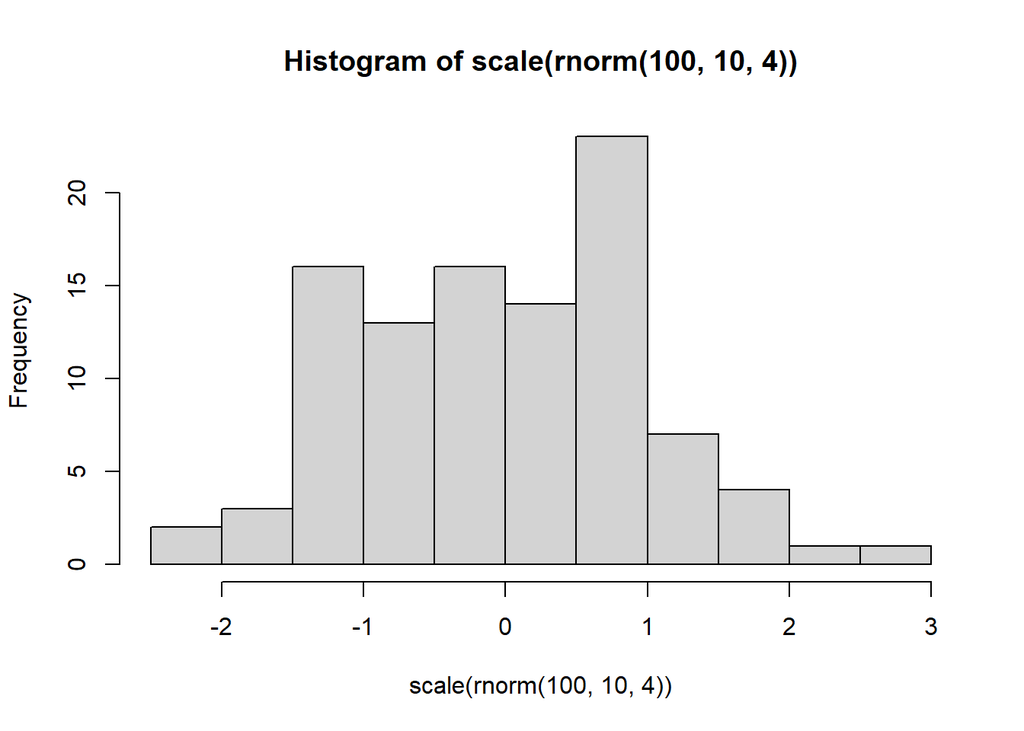

```r
# Chain of calculations using parentheses
hist(scale(rnorm(100, 10, 4)))
```

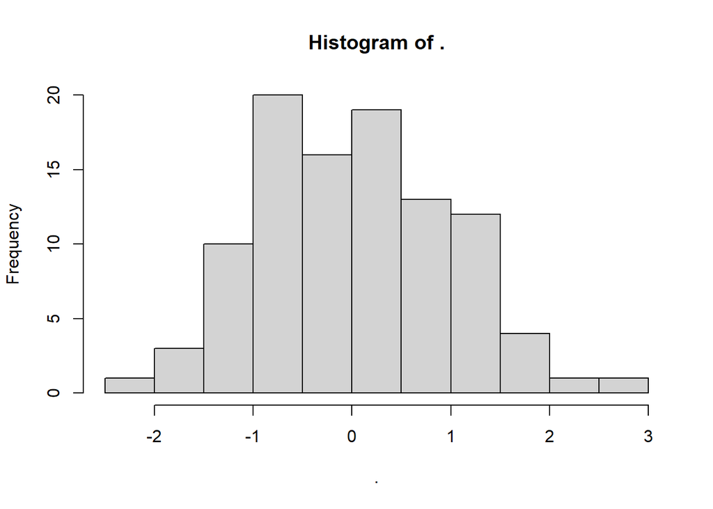

```r
# Chain of Calculations using pipes
rnorm(100, 10, 4) %>%
  scale() %>%
  hist()
```

# Income, age, and race (two different categorical variables and one numerical)

In ggplot, the type of bar or col chart is determined by position. Position is set equal to one of the following:

- identity
- stack (default)
- dodge
- fill

## Identity

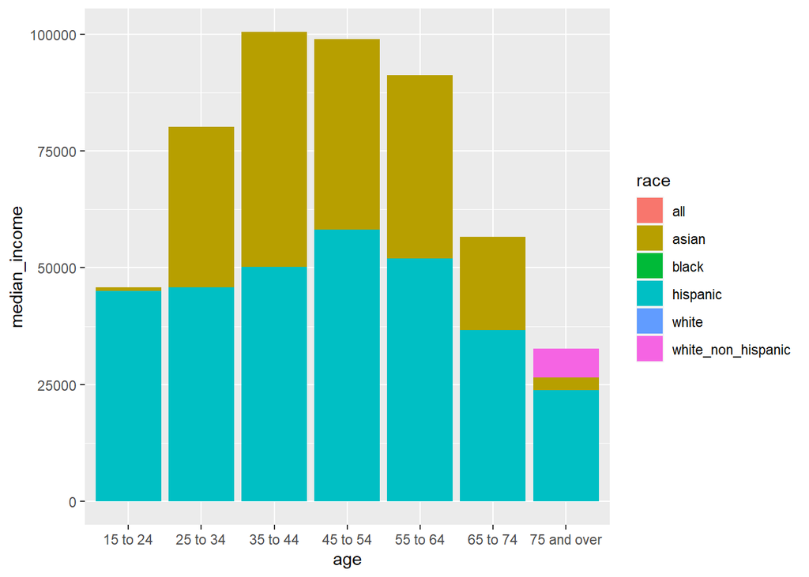

```r
income_by_age %>%
  ggplot(aes(x = age, y = median_income, fill = race)) +
  geom_col(position = "identity")
```

## Stack

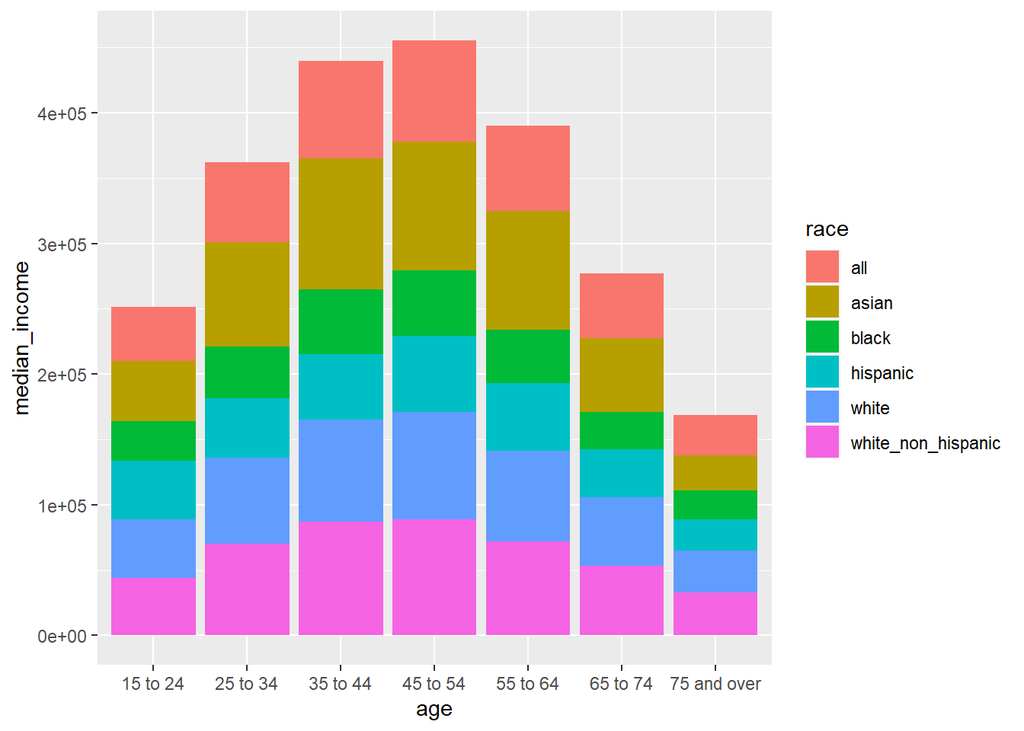

```r
income_by_age %>%
  ggplot(aes(x = age, y = median_income, fill = race)) +
  geom_col(position = "stack")
```

## Dodge

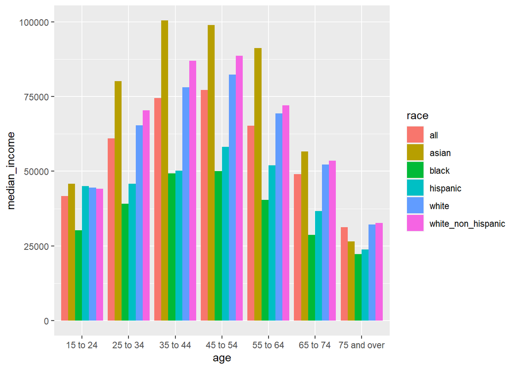

```r
income_by_age %>%
  ggplot(aes(x = age, y = median_income, fill = race)) +
  geom_col(position = "dodge")
```

## Dodge with alternative color palette

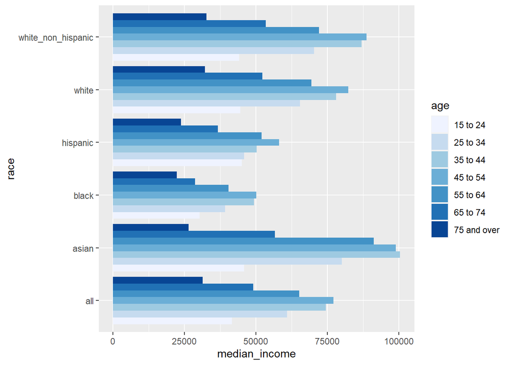

```r
income_by_age %>%
  ggplot(aes(y = race, x = median_income, fill = age)) +
  geom_col(position = "dodge") +
  scale_fill_brewer(palette = "Blues")
```

## Fill gives proportions

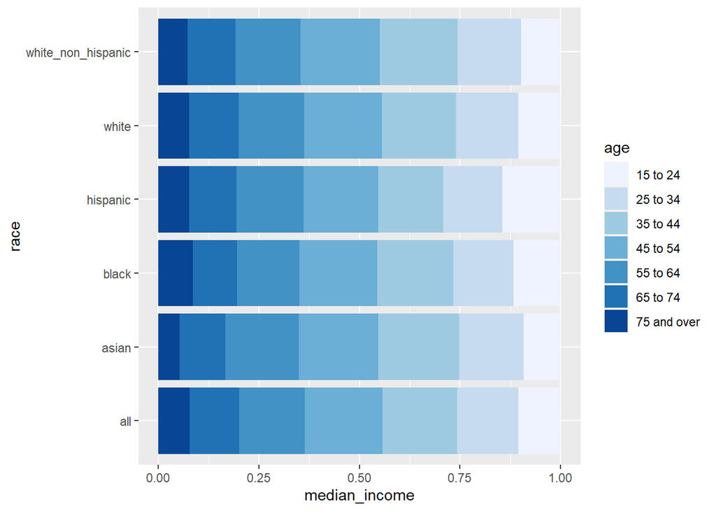

```r
income_by_age %>%
  ggplot(aes(y = race, x = median_income, fill = age)) +
  geom_col(position = "fill") +
  scale_fill_brewer(palette = "Blues")
```

# Titanic

## Horizontal bar chart that shows survival by sex

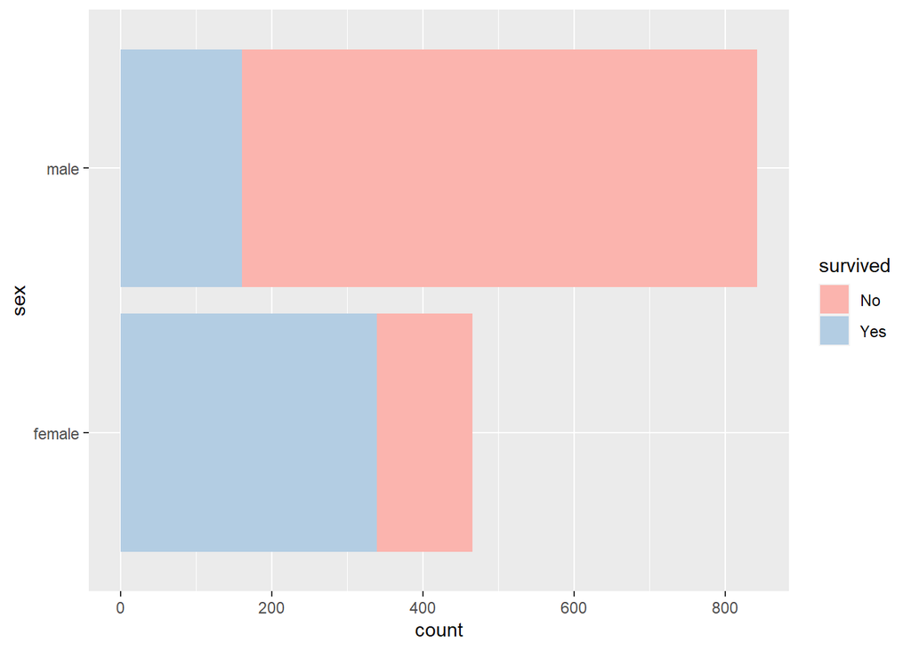

```r
titanic %>%
  ggplot(aes(y = sex, fill = survived)) +
  geom_bar() +
  scale_fill_brewer(palette = "Pastel1")
```

## Horizontal bar chart that shows survival probability by sex

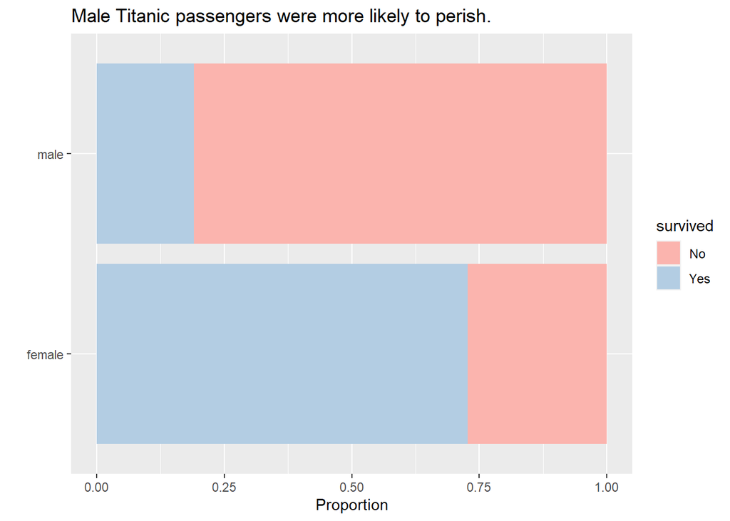

```r
titanic %>%
  ggplot(aes(y = sex, fill = survived)) +
  geom_bar(position = "fill") +
  scale_fill_brewer(palette = "Pastel1") +
  labs(
    title = "Male Titanic passengers were more likely to perish.",
    y = "",
    x = "Proportion"
  )
```

## Horizontal Bar Chart that shows sex by passenger class

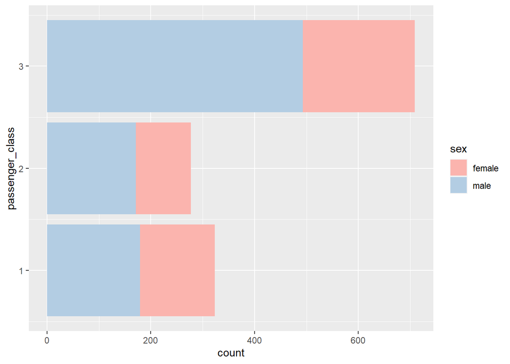

```r
titanic %>%
  ggplot(aes(y = passenger_class, fill = sex)) +
  geom_bar() +
  scale_fill_brewer(palette = "Pastel1")
```

## Bar chart with faceting

- bar chart of passenger class
- fill by sex
- use the Pastel1 color brewer
- faceting by survived

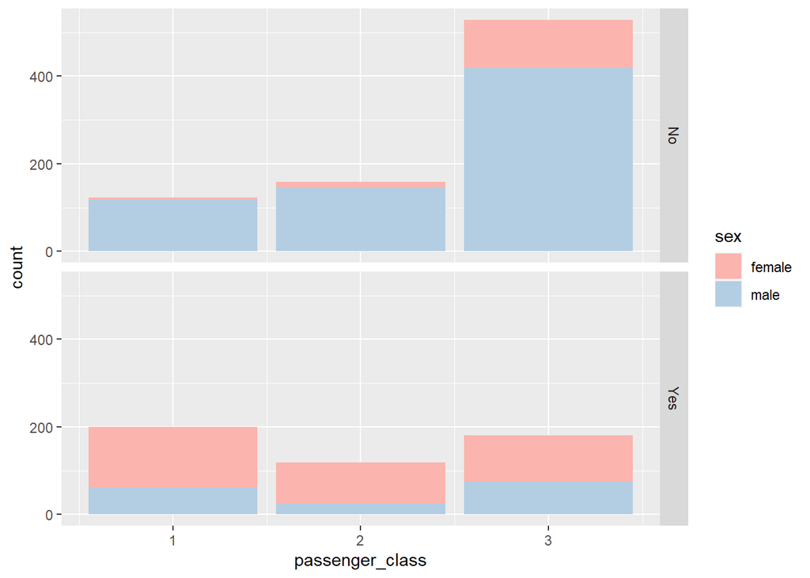

```r
titanic %>%
  ggplot(aes(x = passenger_class, fill = sex)) +
  geom_bar() +
  scale_fill_brewer(palette = "Pastel1") +
  facet_grid(vars(survived))
```

## Life expectancy by country in the Americas

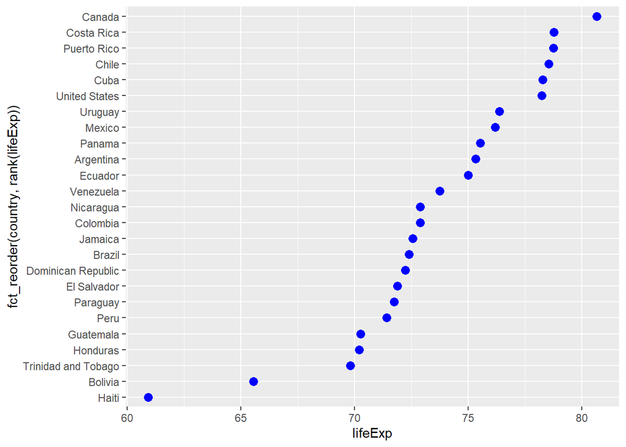

```r
americas %>%
  ggplot(aes(y = fct_reorder(country, rank(lifeExp)),
                                      x = lifeExp)) +
  geom_point(size = 3, color = "blue")
```

## Life expectancy by country using a bar chart

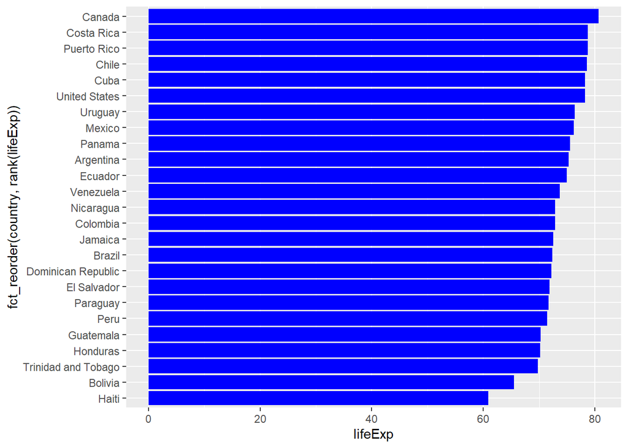

```r
americas %>%
  ggplot(aes(y = fct_reorder(country, rank(lifeExp)),
                                      x = lifeExp)) +
  geom_col( fill = "blue")
```

# Pareto Charts

We use fct_infreq to bar charts of nominal categorical variables. These are called Pareto Charts

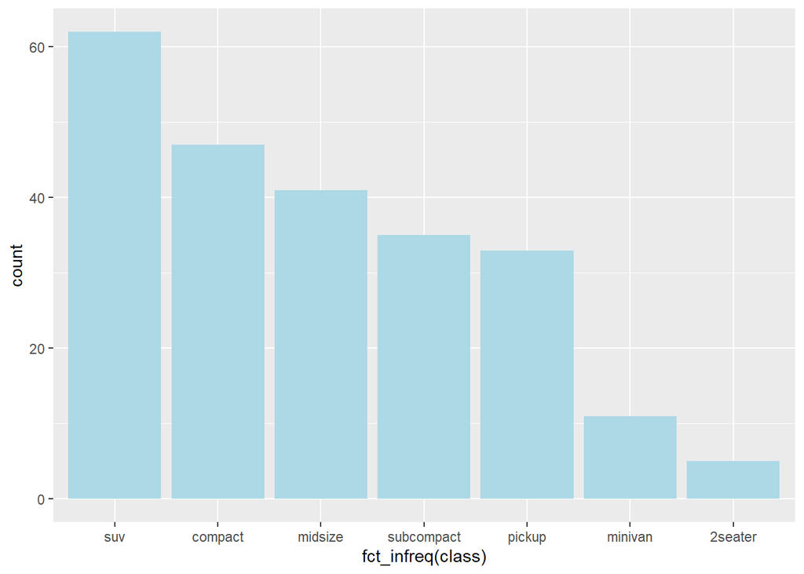

```r
mpg %>%
  ggplot(aes(x = fct_infreq(class))) +
  geom_bar(fill = "lightblue")
```

# Boxoffice data frame

- Revenue from the weekend of December 22 - 24, 2017
- Five top grossing movies

## Horizontal bar chart for the variable title_short

- Use geom_col because we already have amounts
- Fill the bars with light blue
- Flip the axes

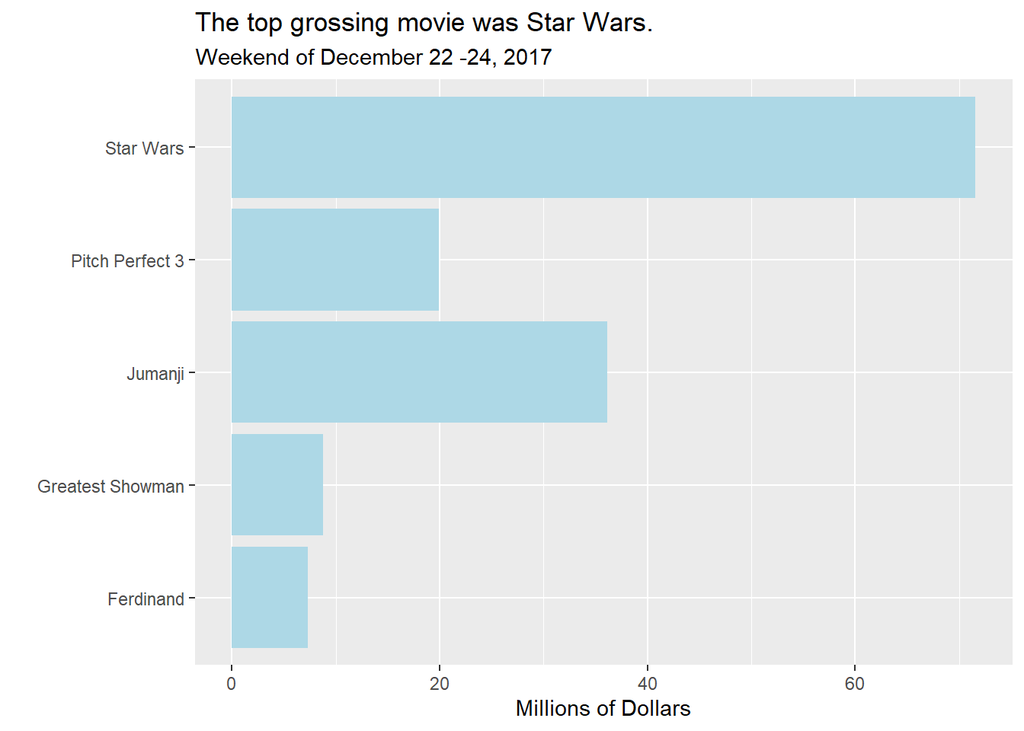

```r
boxoffice %>%
  ggplot(aes(y = title_short, x = amount)) +
  geom_col(fill = "lightblue") +
  labs(
    title = "The top grossing movie was Star Wars.",
    subtitle = "Weekend of December 22 -24, 2017",
    y = "",
    x = "Millions of Dollars"
  )
```

## Pareto chart by sorting bars by the amount of revenue garnered

- Sort the bars using the fct_reorder function and the rank of amount

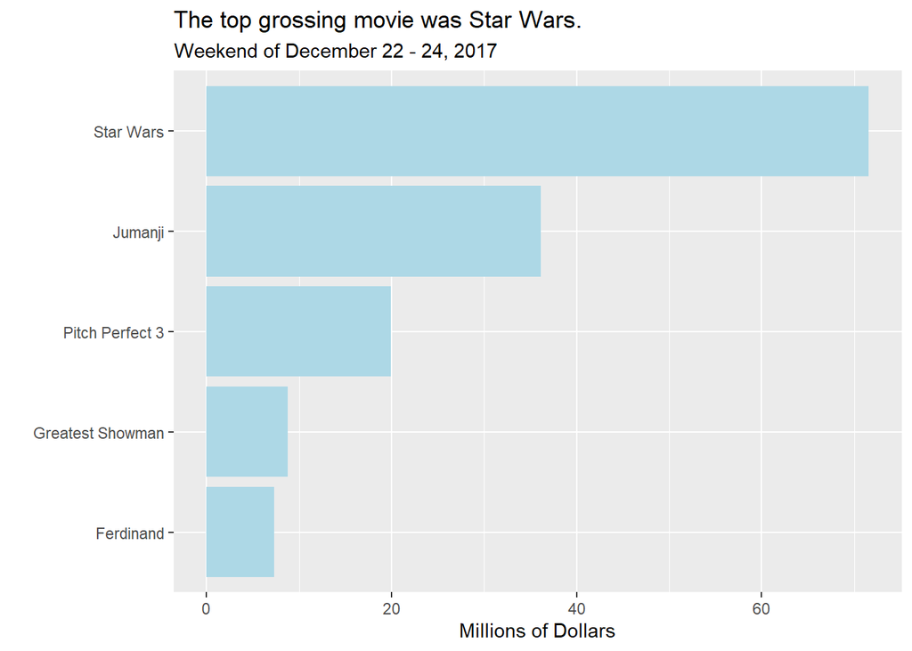

```r
boxoffice %>%
  ggplot(aes(y = fct_reorder(title_short, rank(amount)), x = amount)) +
  geom_col(fill = "lightblue") +
  labs(
    title = "The top grossing movie was Star Wars.",
    subtitle = "Weekend of December 22 - 24, 2017",
    y = "",
    x = "Millions of Dollars"
  )
```